# NIR FGM Model Building

Jimmy Larson

10/5/2021

## Introduction

This file describes the process for building a model for predicting fruitlet abscission rates following a chemical thinner application from Visible/Near Infrared Spectroscopy (NIR) data that was collected in the spring of 2021 in Henderson County, NC. On the cultivar ‘Honeycrisp’ 20 spurs on five trees were tagged, each fruit had their NIR spectra and diameter measured surrounding a chemical thinner application. The thinner application was made on May 2 and final fruit final fruitlet persistence was determined on June 16th. NIR and dimaeter data was collected on:

- April 28 (Measurement 1)
- May 1 (Measurement 2)
- May 5 (Measurement 3)
- May 7 (Measurement 4)
- May 9 (Measurement 5)
- May 11 (Measurement 6)
- May 14 (Measurement 7)

Three different classification models - Logisitic Regression, Random Forest and XGBoost - were tested against the widely available Fruit Growth Model (FGM) that utilizes fruitlet diameter to predict fruitlet abscission. See “FGM_model_test_notes.Rmd” for specifics on FGM model performance. Due to the majority of fruit abscising following the thinner application, Synthetic Minority Oversampling Technique (SMOTE) was tested to determine model performance from balancing the dataset, see “Smote_notes.Rmd” for more information on balancing data with SMOTE. Individual measurement dates and well as the difference in fruitlet absorption between successive dates were compared as well for model building. Where applicable, models were also tested with selected variables.

Each model was built in a separate R scripts - “NIR_PLS_model.R”, “NIR_RF_model.R”, and “NIR_XGBoost_model.R”. For all models, the seed was set at 123:

```r
set.seed(123)
```

## XGBoost

Below describes the process for building a model for each single measurement date (total of 7) and differences in spectra between consecutive measurement dates (total of 6) with and without SMOTE. Then, due to SMOTE outperforming the unbalanced dataset, those datasets were used to test model performance with selected wavelengths.

A dataset was load for single date and difference spectra, with and without SMOTE…

```r
meas1 <- read_csv("data/2021/honeycrisp/model_building/meas1_spectra.csv")
meas1Smoted <- read_csv("data/2021/honeycrisp/model_building/meas1Smoted.csv")
diff1 <- read_csv("data/2021/honeycrisp/model_building/diff1_spectra.csv")
diff1Smoted <- read_csv("data/2021/honeycrisp/model_building/diff1Smoted.csv")
```

### Single Measurement Dates

For unblanced single measurement data, missing values were removed and the predictor and response variables were selected…

```r
meas1 %>%
  drop_na() %>%
  select(persistCode, 6:311) -> meas1
```

```r
meas1Cases <- as.data.frame(table(meas1$persistCode))
meas1Per <- meas1Cases[1,2]
meas1Abs <- meas1Cases[2,2]
```

Data had to then be prepared for xgboost model by converting to a matrix and then to a matrix of class xgb.DMatrix. xgb.DMatrix first takes the predictor variables and then specifies the response as the label.

```r
meas1 <- data.matrix(meas1)
xgbMeas1data <- xgb.DMatrix(meas1[,-1], label = meas1[,1])
```

Using the xgb.Dmatrix, an XGBoost model is then built. Because this is a classification problem, a “binary:logistic” model was chosen. This model was 5 fold cross validated and 3 iterations of the model were built. These parameters will be used in all successive XGBoost models.

```r
xgbMeas1 <- xgb.cv(data = xgbMeas1data,
                   nround=3,
                   nfold = 5,
                   metrics = list("error","rmse","auc"),
                   scale_pos_weight = meas1Abs/meas1Per,
                   max_depth = 4,
                   eta = .3,
                   prediction = TRUE,
                   objective = "binary:logistic")
```

### Single Measurement Dates Balanced with SMOTE

Since SMOTE balances data, we do not need to first calculate the ratio of abscised to persisted fruit and can go into changing the class of data and running the model.

```r
meas1SmotedMatrix <- data.matrix(meas1Smoted)
xgbMeas1Smoted <- xgb.DMatrix(meas1SmotedMatrix[,-1], label = meas1SmotedMatrix[,1])
xgbMeas1SmotedCv <- xgb.cv(data = xgbMeas1Smoted,
                           nfold = 5,
                           nrounds = 3,
                           max_depth = 4,
                           eta = .3,
                           objective = "binary:logistic",
                           prediction = TRUE,
                           metrics = list("error","rmse","auc"))
```

### Difference in Spectra

The unbalanced difference in spectra model follows the same process as the single measurement date above…

```r
diff1 %>%
  drop_na() %>%
  select(persistCode, 6:311) -> diff1
diff1Cases <- as.data.frame(table(diff1$persistCode))
diff1Per <- diff1Cases[1,2]
diff1Abs <- diff1Cases[2,2]
diff1Matrix <- data.matrix(diff1)
xgbDiff1Data <- xgb.DMatrix(diff1Matrix[,-1], label= diff1Matrix[,1])
xgbDiff1Cv <- xgb.cv(data = xgbDiff1Data,
                     nfold = 5,
                     nrounds = 3,
                     scale_pos_weight = diff1Abs/diff1Per,
                     max_depth = 4,
                     eta = .3,
                     objective = "binary:logistic",
                     prediction = TRUE,
                     metrics = list("error", "rmse", "auc"))
```

### Difference in Spectra Balanced with SMOTE

As with the unblanced difference spectra model, the SMOTE balanced model building steps are the same as the single measurement dates

```r
diff1SmotedMatrix <- data.matrix(diff1Smoted)
xgbdiff1Smoted <- xgb.DMatrix(diff1SmotedMatrix[,-1], label = diff1SmotedMatrix[,1])
xgbdiff1SmotedCv <- xgb.cv(data = xgbdiff1Smoted,
                           nfold = 5,
                           nrounds = 3,
                           max_depth = 4,
                           eta = .3,
                           objective = "binary:logistic",
                           prediction = TRUE,
                           metrics = list("error","rmse","auc"))
```

### Selected Wavelengths on Single Measurement Dates

To build a model with the most important wavelengths, a model is built from the full dataset, using xgb.train and the same parameters as the XGBoost models above.

```r
xgbMeas1SmotedTrain <- xgb.train(data = xgbMeas1Smoted,
                           nfold = 5,
                           nrounds = 3,
                           max_depth = 4,
                           eta = .3,
                           objective = "binary:logistic")
```

A matrix with each variables ‘gain’ - how much it contributes to the model - is returned from the xgb.importance function.

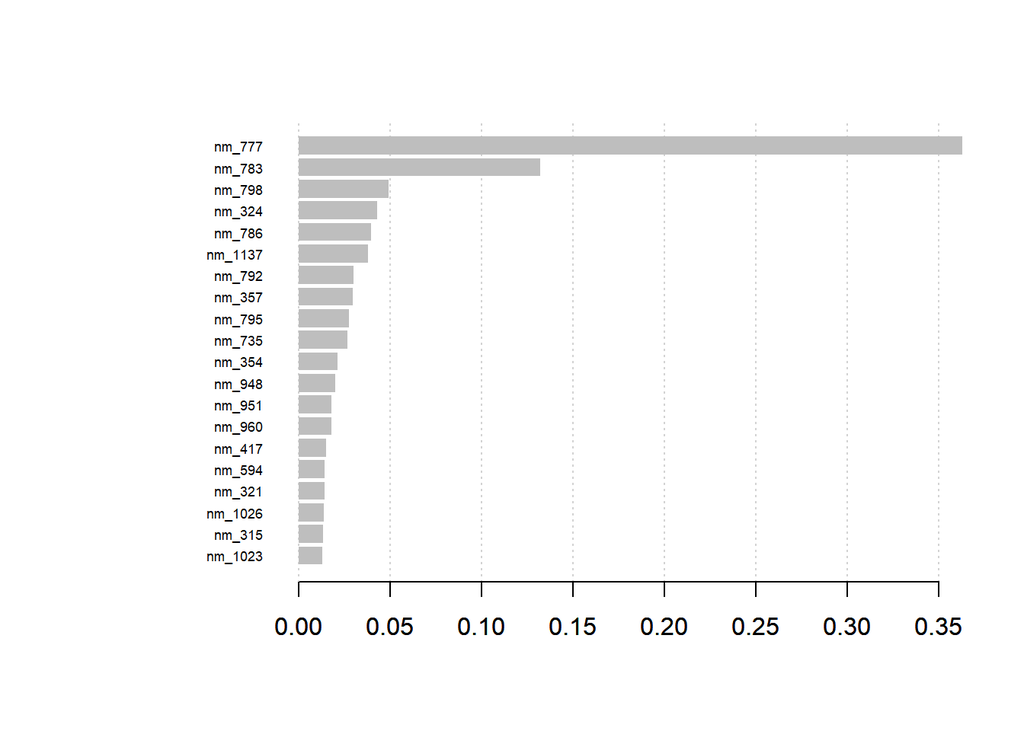

```r
xgbMeas1SmotedTrain <- xgb.train(data = xgbMeas1Smoted,
                           nfold = 5,
                           nrounds = 3,
                           max_depth = 4,
                           eta = .3,
                           objective = "binary:logistic")
xgbMeas1SmotedImp <- xgb.importance(feature_names = colnames(meas1Smoted[,-1]), model = xgbMeas1SmotedTrain)
xgb.plot.importance(importance_matrix = xgbMeas1SmotedImp[1:20])
```

From the plot of the 20 most important features, a cut off of 0.025 was chosen for the selected model.

```r
xgbMeas1SmotedImp %>%
  filter(Gain >= 0.025) -> xgbMeas1SmotedImpFeat
```

These are then selected from the original dataset

```r
xgbMeas1SmotedSelectedFeat <- xgbMeas1SmotedImpFeat$Feature
meas1Smoted %>%
  select(`meas1Smote$Y`, xgbMeas1SmotedSelectedFeat) %>%
  data.matrix() -> meas1SmotedSelectedMatrix
```

This model is then built using cross validation, as above.

```r
xgbMeas1SmotedSelected <- xgb.DMatrix(meas1SmotedSelectedMatrix[,-1], label = meas1SmotedSelectedMatrix[,1])
xgbMeas1SmotedSelectedCv <- xgb.cv(data = xgbMeas1SmotedSelected,
                           nfold = 5,
                           nrounds = 3,
                           max_depth = 4,
                           eta = .3,
                           objective = "binary:logistic",
                           prediction = TRUE,
                           metrics = list("error","rmse","auc"))
```

### Selected Wavelengths on Difference between Dates

A selected wavelengths model for differences in absorption was built using the same process.

```r
xgbDiff1SmotedTrain <- xgb.train(data = xgbdiff1Smoted,
                                 nfold = 5,
                                 nrounds = 3,
                                 max_depth = 4,
                                 eta = .3,
                                 objective = "binary:logistic")
xgbDiff1SmotedImp <- xgb.importance(feature_names = colnames(diff1Smoted[,-1]), model = xgbDiff1SmotedTrain)
xgb.plot.importance(importance_matrix = xgbDiff1SmotedImp[1:20])
xgbDiff1SmotedImp %>%
  filter(Gain >= 0.025) -> xgbDiff1SmotedImpFeat
xgbDiff1SmotedSelectedFeat <- xgbDiff1SmotedImpFeat$Feature
diff1Smoted %>%
  select(`diff1Smote$Y`, xgbDiff1SmotedSelectedFeat) %>%
  data.matrix() -> diff1SmotedSelectedMatrix
xgbDiff1SmotedSelected <- xgb.DMatrix(diff1SmotedSelectedMatrix[,-1], label = diff1SmotedSelectedMatrix[,1])
xgbDiff1SmotedSelectedCv <- xgb.cv(data = xgbDiff1SmotedSelected,
                                   nfold = 5,
                                   nrounds = 3,
                                   max_depth = 4,
                                   eta = .3,
                                   objective = "binary:logistic",
                                   prediction = TRUE,
                                   metrics = list("error","rmse","auc"))
```

[output not shown]

### Comparison of XGBoost Models

XGBoost Model Metrics

| Days after Thinner | Single Date Error | Single Date SMOTE Error | Diff. Between Dates Error | Diff. Between Dates SMOTE Error | Single Date Selected Error | Diff. Between Dates Selected Error | Single Date AUC | Single Date SMOTE AUC | Diff. Between Dates AUC | Diff. Between Dates SMOTE AUC | Single Date Selected AUC | Diff. Between Dates Selected AUC |
| --- | --- | --- | --- | --- | --- | --- | --- | --- | --- | --- | --- | --- |
| -4 | 0.15 | 0.18 | - | - | 0.19 | - | 0.56 | 0.88 | - | - | 0.86 | - |
| -1 | 0.17 | 0.16 | 0.17 | 0.22 | 0.17 | 0.20 | 0.51 | 0.90 | 0.50 | 0.86 | 0.88 | 0.87 |
| 3 | 0.18 | 0.20 | 0.17 | 0.16 | 0.19 | 0.16 | 0.59 | 0.89 | 0.60 | 0.91 | 0.90 | 0.91 |
| 5 | 0.18 | 0.17 | 0.18 | 0.21 | 0.18 | 0.19 | 0.67 | 0.91 | 0.57 | 0.88 | 0.89 | 0.87 |
| 7 | 0.25 | 0.17 | 0.21 | 0.18 | 0.15 | 0.18 | 0.69 | 0.90 | 0.58 | 0.91 | 0.91 | 0.89 |
| 9 | 0.15 | 0.08 | 0.23 | 0.14 | 0.09 | 0.12 | 0.86 | 0.96 | 0.66 | 0.94 | 0.96 | 0.94 |
| 12 | 0.18 | 0.08 | 0.28 | 0.18 | 0.07 | 0.17 | 0.86 | 0.96 | 0.59 | 0.91 | 0.96 | 0.91 |